# **Machine Maintenance Predictor**

```python
import warnings
warnings.filterwarnings("ignore")
import os
import kaggle
import pandas as pd
import numpy as np
%matplotlib inline
import matplotlib.pyplot as plt
import seaborn as sns
import statistics
from zlib import crc32
from sklearn.impute import SimpleImputer
from sklearn.preprocessing import OneHotEncoder
from sklearn.pipeline import Pipeline
from sklearn.preprocessing import StandardScaler
from sklearn.compose import ColumnTransformer
import time
import tensorflow as tf
from tensorflow import keras
from scikeras.wrappers import KerasRegressor
from keras import regularizers
from keras import activations
from keras.layers import BatchNormalization, LeakyReLU
from keras.callbacks import ReduceLROnPlateau
from sklearn.model_selection import RandomizedSearchCV
```

## **Import Data From Kaggle**

We are using the "Machine Predictive Maintenance Classification" dataset from "https://www.kaggle.com/datasets/shivamb/machine-predictive-maintenance-classification"

```python
kaggleDataset = "shivamb/machine-predictive-maintenance-classification"
datasetPath = os.path.join("dataset", "Predictive Maintenance")
```

```python
# Check if the dataset folder already exists
if os.path.exists(datasetPath):
    download = input("The dataset may already be downloaded. Do you want to download and replace it? (Y/N): ").strip().upper()
    if download == 'Y':
        kaggle.api.dataset_download_files(kaggleDataset, datasetPath, unzip=True)
        print("Dataset downloaded and unzipped.")
    else:
        print("Skipping download.")
else:
    # Download if the dataset folder doesn't exist
    kaggle.api.dataset_download_files(kaggleDataset, datasetPath, unzip=True)
    print("Dataset downloaded and unzipped.")
```

```
Skipping download.
```

```python
def loadPredictiveMaintenance(datasetPath = datasetPath):
    csvPath = os.path.join(datasetPath, "predictive_maintenance.csv")
    return pd.read_csv(csvPath, engine='python', on_bad_lines='skip')
```

```python
MaintenanceData = loadPredictiveMaintenance()
```

## **Data Wrangling: Converting temperature units and adjusting tool wear time**

```python
MaintenanceData["Air temperature [K]"] = MaintenanceData["Air temperature [K]"] - 272.15
MaintenanceData["Process temperature [K]"] = MaintenanceData["Process temperature [K]"] - 272.15
MaintenanceData["Tool wear [min]"] = MaintenanceData["Tool wear [min]"] * 60

MaintenanceData.rename(columns={
    "Air temperature [K]" : "Air temperature [°C]",
    "Process temperature [K]" : "Process temperature [°C]",
    "Tool wear [min]" : "Tool wear [sec]"
    },inplace=True)

MaintenanceData["Temperature difference [°C]"] = MaintenanceData["Process temperature [°C]"] - MaintenanceData["Air temperature [°C]"]
```

## **Data Exploration: Understanding the dataset structure and summary statistics**

Let's explore the dataset to get a sense of its structure, data types, and basic statistics.

```python
MaintenanceData.head()
```

|  | UDI | Product ID | Type | Air temperature [°C] | Process temperature [°C] | Rotational speed [rpm] | Torque [Nm] | Tool wear [sec] | Target | Failure Type | Temperature difference [°C] |
| --- | --- | --- | --- | --- | --- | --- | --- | --- | --- | --- | --- |
| 0 | 1 | M14860 | M | 25.95 | 36.45 | 1551 | 42.8 | 0 | 0 | No Failure | 10.5 |
| 1 | 2 | L47181 | L | 26.05 | 36.55 | 1408 | 46.3 | 180 | 0 | No Failure | 10.5 |
| 2 | 3 | L47182 | L | 25.95 | 36.35 | 1498 | 49.4 | 300 | 0 | No Failure | 10.4 |
| 3 | 4 | L47183 | L | 26.05 | 36.45 | 1433 | 39.5 | 420 | 0 | No Failure | 10.4 |
| 4 | 5 | L47184 | L | 26.05 | 36.55 | 1408 | 40.0 | 540 | 0 | No Failure | 10.5 |

```python
MaintenanceData.info()
```

```
<class 'pandas.core.frame.DataFrame'>
RangeIndex: 10000 entries, 0 to 9999
Data columns (total 11 columns):
 #   Column                       Non-Null Count  Dtype
---  ------                       --------------  -----
 0   UDI                          10000 non-null  int64
 1   Product ID                   10000 non-null  object
 2   Type                         10000 non-null  object
 3   Air temperature [°C]         10000 non-null  float64
 4   Process temperature [°C]     10000 non-null  float64
 5   Rotational speed [rpm]       10000 non-null  int64
 6   Torque [Nm]                  10000 non-null  float64
 7   Tool wear [sec]              10000 non-null  int64
 8   Target                       10000 non-null  int64
 9   Failure Type                 10000 non-null  object
 10  Temperature difference [°C]  10000 non-null  float64
dtypes: float64(4), int64(4), object(3)
memory usage: 859.5+ KB
```

```python
MaintenanceData.describe()
```

|  | UDI | Air temperature [°C] | Process temperature [°C] | Rotational speed [rpm] | Torque [Nm] | Tool wear [sec] | Target | Temperature difference [°C] |
| --- | --- | --- | --- | --- | --- | --- | --- | --- |
| count | 10000.00000 | 10000.000000 | 10000.000000 | 10000.000000 | 10000.000000 | 10000.000000 | 10000.000000 | 10000.000000 |
| mean | 5000.50000 | 27.854930 | 37.855560 | 1538.776100 | 39.986910 | 6477.060000 | 0.033900 | 10.000630 |
| std | 2886.89568 | 2.000259 | 1.483734 | 179.284096 | 9.968934 | 3819.248798 | 0.180981 | 1.001094 |
| min | 1.00000 | 23.150000 | 33.550000 | 1168.000000 | 3.800000 | 0.000000 | 0.000000 | 7.600000 |
| 25% | 2500.75000 | 26.150000 | 36.650000 | 1423.000000 | 33.200000 | 3180.000000 | 0.000000 | 9.300000 |
| 50% | 5000.50000 | 27.950000 | 37.950000 | 1503.000000 | 40.100000 | 6480.000000 | 0.000000 | 9.800000 |
| 75% | 7500.25000 | 29.350000 | 38.950000 | 1612.000000 | 46.800000 | 9720.000000 | 0.000000 | 11.000000 |
| max | 10000.00000 | 32.350000 | 41.650000 | 2886.000000 | 76.600000 | 15180.000000 | 1.000000 | 12.100000 |

## **Data Visualization: Gaining insights through distributions, categories, and relationships**

Let's use Seaborn to explore the dataset visually. We'll start by plotting histograms with KDE and boxplots for the numerical features to understand their distributions and spot any outliers. Next, we'll visualize the categorical features using bar plots and pie charts to examine class distributions. Finally, we'll use scatter and relational plots to explore the relationship between torque, rotational speed, and failure types across different machine types.

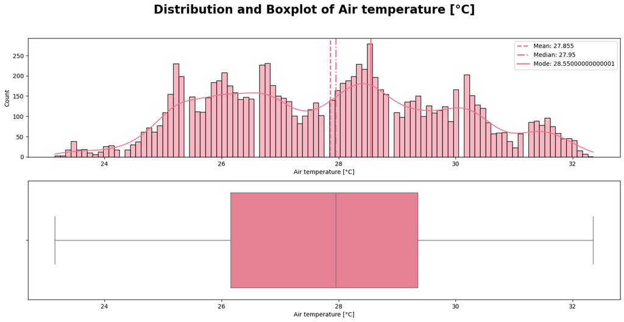

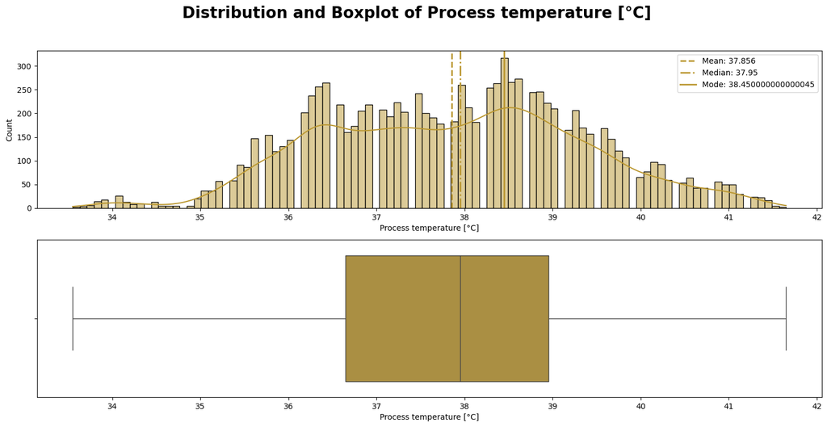

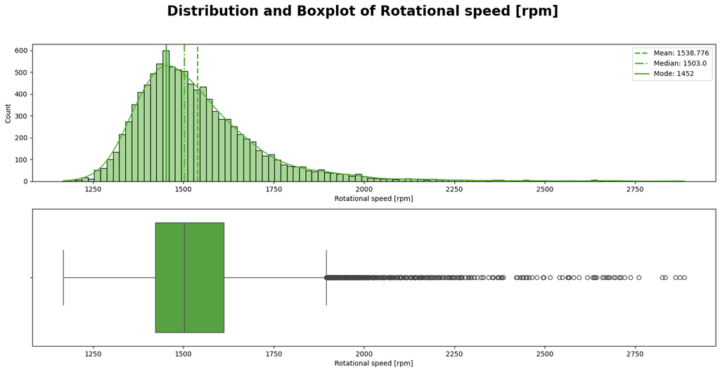

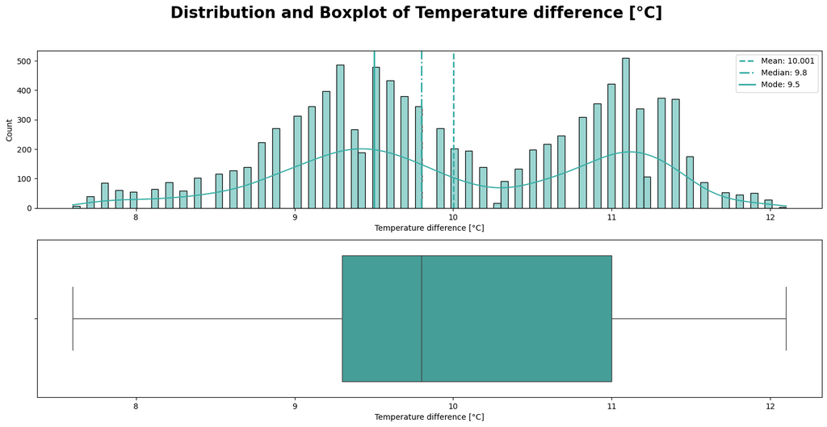

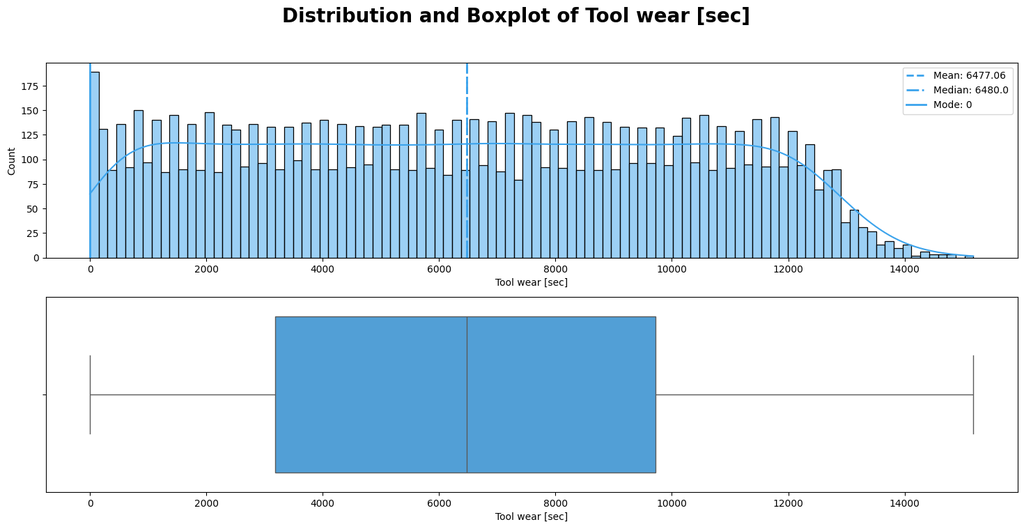

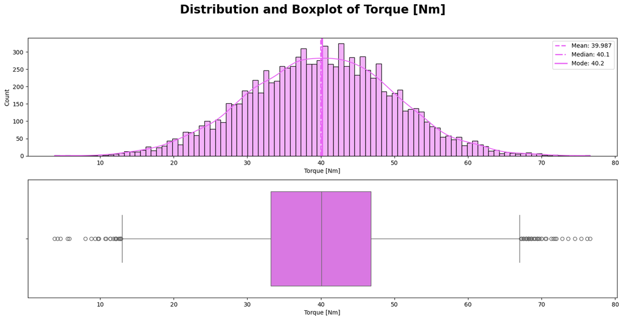

```python
numeric_columns = MaintenanceData.select_dtypes(include=['number']).columns.difference(["UDI", "Target"])

colors = sns.color_palette("husl", len(numeric_columns))

for i, col in enumerate(numeric_columns):
    fig, ax = plt.subplots(2, 1, figsize=(18, 8))

    fig.suptitle(f"Distribution and Boxplot of {col}", fontsize=20, fontweight='bold')

    sns.histplot(data = MaintenanceData[col], kde = True, bins=100, ax = ax[0],color=colors[i])

    ax[0].axvline(x = MaintenanceData[col].mean(), color=colors[i], linestyle = '--', linewidth = 2, label = 'Mean: {}'.format(round(MaintenanceData[col].mean(), 3)))
    ax[0].axvline(x = MaintenanceData[col].median(), color=colors[i], linestyle = '-.', linewidth = 2, label = 'Median: {}'.format(round(MaintenanceData[col].median(), 3)))
    ax[0].axvline(x = statistics.mode(MaintenanceData[col]), color=colors[i], linewidth = 2, label = 'Mode: {}'.format(MaintenanceData[col].mode().iloc[0]))
    ax[0].legend()

    sns.boxplot(x = MaintenanceData[col], ax = ax[1],color=colors[i])
    plt.show()
```

### Takeaways:

```
Type
L    60.00
M    29.97
H    10.03
Name: proportion, dtype: float64
```

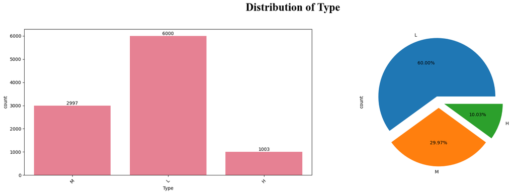

```
Target
0    96.61
1     3.39
Name: proportion, dtype: float64
```

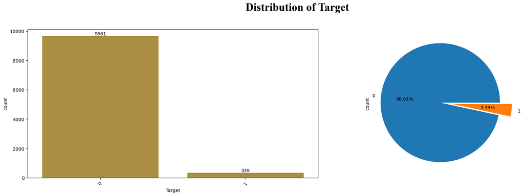

```
Failure Type
No Failure                  96.52
Heat Dissipation Failure     1.12
Power Failure                0.95
Overstrain Failure           0.78
Tool Wear Failure            0.45
Random Failures              0.18
Name: proportion, dtype: float64
```

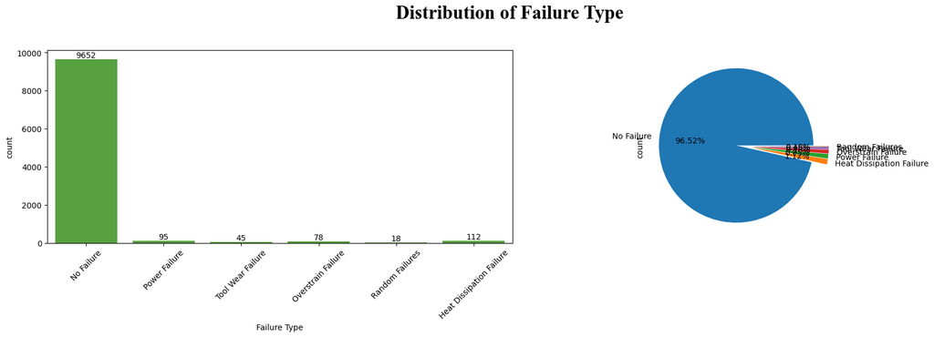

```python
for i, col in enumerate(MaintenanceData[['Type', 'Target', 'Failure Type']].columns):
    Percentage = MaintenanceData[col].value_counts(normalize=True) * 100
    display(Percentage)

    fig, axes = plt.subplots(1, 2, figsize=(18, 6))
    fig.suptitle(f"Distribution of {col}", fontsize=24, fontweight='bold', font='Times New Roman', color='black')

    sns.countplot(x=col, data=MaintenanceData, color=colors[i], ax=axes[0])
    axes[0].tick_params(axis='x', rotation=45)
    axes[0].bar_label(axes[0].containers[0])

    counts = MaintenanceData[col].value_counts()
    explode = [0.1] * len(counts)
    counts.plot.pie(explode=explode, autopct='%1.2f%%', ax=axes[1])

    plt.tight_layout(rect=[0, 0, 1, 0.95])
    plt.show()
```

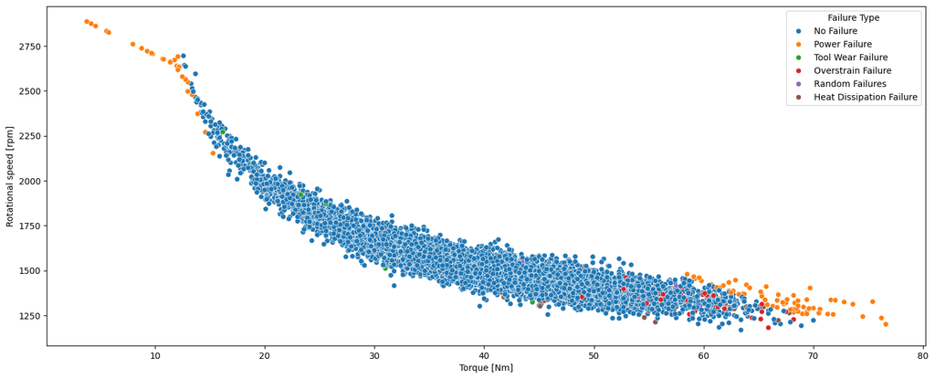

```python
plt.figure(figsize=(18,7))

sns.scatterplot(MaintenanceData, x="Torque [Nm]", y="Rotational speed [rpm]", hue="Failure Type", palette="tab10")
```

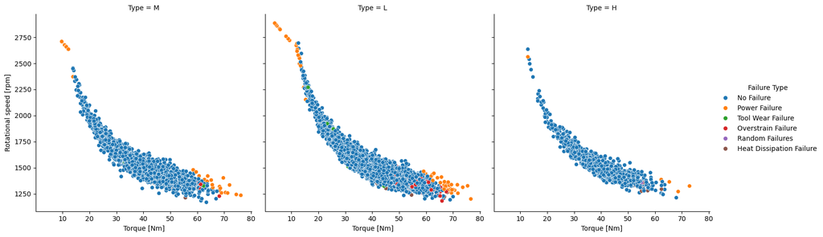

```python
sns.relplot(MaintenanceData, x="Torque [Nm]", y="Rotational speed [rpm]", hue="Failure Type", col="Type", palette='tab10')
```

### Takeaway:

- We can visually see that Torque and Rotational Speed do have a clear relationship with Failure Type. Most failures happen when Torque is low and Rotational Speed is high, and also when Torque is high and Rotational Speed is low.

We know that `Failure Type` will give us what `Target` gives out but in more detail, so there is no need to predict what `Target` is if `Failure Type` is being predicted already. We can then drop `Target` from our dataset.

```python
MaintenanceData.drop('Target', axis=1, inplace=True)
```

We can also factorize our Failure Type, so that it can be a number represented by a separate labels list.

```python
MaintenanceData['Failure Type'], Failure_Type_labels = pd.factorize(MaintenanceData['Failure Type'])
```

```python
MaintenanceData.head()
```

|  | UDI | Product ID | Type | Air temperature [°C] | Process temperature [°C] | Rotational speed [rpm] | Torque [Nm] | Tool wear [sec] | Failure Type | Temperature difference [°C] |
| --- | --- | --- | --- | --- | --- | --- | --- | --- | --- | --- |
| 0 | 1 | M14860 | M | 25.95 | 36.45 | 1551 | 42.8 | 0 | 0 | 10.5 |
| 1 | 2 | L47181 | L | 26.05 | 36.55 | 1408 | 46.3 | 180 | 0 | 10.5 |
| 2 | 3 | L47182 | L | 25.95 | 36.35 | 1498 | 49.4 | 300 | 0 | 10.4 |
| 3 | 4 | L47183 | L | 26.05 | 36.45 | 1433 | 39.5 | 420 | 0 | 10.4 |
| 4 | 5 | L47184 | L | 26.05 | 36.55 | 1408 | 40.0 | 540 | 0 | 10.5 |

```python
print(Failure_Type_labels)
```

```
Index(['No Failure', 'Power Failure', 'Tool Wear Failure',
       'Overstrain Failure', 'Random Failures', 'Heat Dissipation Failure'],
      dtype='object')
```

## **Creating Train, Valid, and Test Sets**

In order to ensure that our train, valid, and test sets stays consistent no matter how many times we rerun the program or update the dataset, we want to use a unique identifier to help us decide if the row should go into the test set or not. We can compute a hash for each row's unique identifier and use it to split our dataset.

```python
def IDTest(ID):
    return (crc32(np.int64(ID)) & 0xffffffff) / 2**32

def splitTrainValidTestByID(dataset, trainRatio, validRatio, ID):
    assert trainRatio + validRatio < 1, "Train + Validation ratios must be less than 1 (leaving space for test set)."

    IDs = dataset[ID].apply(IDTest)

    trainSet = dataset[IDs < trainRatio]
    validSet = dataset[(IDs >= trainRatio) & (IDs < trainRatio + validRatio)]
    testSet = dataset[IDs >= trainRatio + validRatio]

    return trainSet, validSet, testSet
```

```python
trainSet, validSet, testSet = splitTrainValidTestByID(MaintenanceData, trainRatio=0.7, validRatio=0.15, ID='UDI')
```

```python
len(trainSet) / len(MaintenanceData) # training set should be 70%
```

```
0.6998
```

```python
len(validSet) / len(MaintenanceData) # training set should be 15%
```

```
0.1501
```

```python
len(testSet) / len(MaintenanceData) # training set should be 15%
```

```
0.1501
```

With our three datasets made, we can drop UDI and Product ID, as we do not want these identifiers affecting our training and results.

```python
for set_ in (trainSet, validSet, testSet):
    set_.drop('UDI', axis=1, inplace=True)
    set_.drop('Product ID', axis=1, inplace=True)
```

## **Numerical Feature Analysis: Correlation and Pairwise Relationships**

Let's focus on the numerical features by examining their correlation with the target variable and visualizing pairwise relationships using Seaborn's `pairplot`. This helps identify potential patterns and dependencies among the features with respect to failure types.

```python
train_numeric_attribs = trainSet.select_dtypes(include=['float64', 'int64'])
corr_matrix = train_numeric_attribs.corr()
```

```python
corr_matrix["Failure Type"].sort_values(ascending=False)
```

```
Failure Type                   1.000000
Torque [Nm]                    0.200896
Air temperature [°C]           0.117129
Tool wear [sec]                0.074413
Process temperature [°C]       0.052853
Rotational speed [rpm]        -0.126369
Temperature difference [°C]   -0.155680
Name: Failure Type, dtype: float64
```

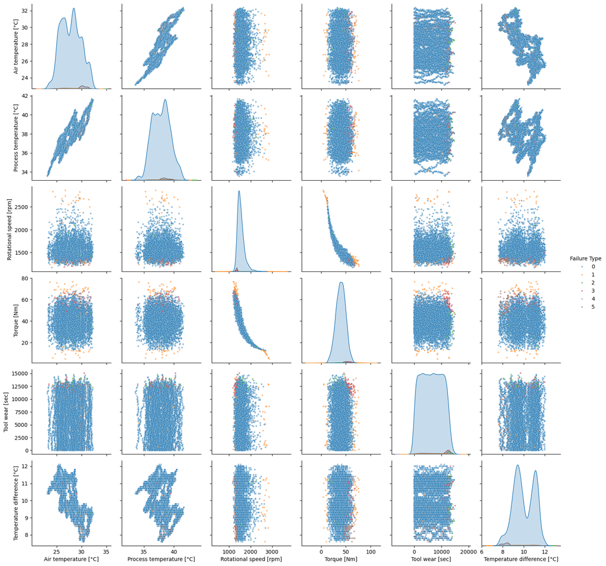

```python
matrix_attributes = trainSet.select_dtypes(include=['number']).columns
sns.pairplot(trainSet[matrix_attributes], diag_kind='kde', hue='Failure Type', palette='tab10', plot_kws={'alpha':0.5, 's':10})
plt.show()
```

```python
X_train = trainSet.drop(["Failure Type"], axis=1)
y_train = trainSet[["Failure Type"]].copy()
```

```python
X_train.head()
```

|  | Type | Air temperature [°C] | Process temperature [°C] | Rotational speed [rpm] | Torque [Nm] | Tool wear [sec] | Temperature difference [°C] |
| --- | --- | --- | --- | --- | --- | --- | --- |
| 0 | M | 25.95 | 36.45 | 1551 | 42.8 | 0 | 10.5 |
| 1 | L | 26.05 | 36.55 | 1408 | 46.3 | 180 | 10.5 |
| 4 | L | 26.05 | 36.55 | 1408 | 40.0 | 540 | 10.5 |
| 5 | M | 25.95 | 36.45 | 1425 | 41.9 | 660 | 10.5 |
| 6 | L | 25.95 | 36.45 | 1558 | 42.4 | 840 | 10.5 |

```python
y_train.head()
```

|  | Failure Type |
| --- | --- |
| 0 | 0 |
| 1 | 0 |
| 4 | 0 |
| 5 | 0 |
| 6 | 0 |

## **Handling Missing Values: Imputing numerical features**

There are no null values for our numeric features, but let's just include a SimpleImputer just in case there is and we can replace them with the median. This ensures we don't have to worry that our model can train effectively without being affected by missing data.

```python
X_train_numeric_attribs = X_train.select_dtypes(include=['float64', 'int64'])

imputer = SimpleImputer(strategy="median")
imputer.fit(X_train_numeric_attribs)
```

```
SimpleImputer(strategy='median')
```

```python
imputer.statistics_
```

```
array([  27.95,   37.95, 1504.  ,   40.  , 6480.  ,    9.8 ])
```

```python
X_train_numeric_attribs.median().values
```

```
array([  27.95,   37.95, 1504.  ,   40.  , 6480.  ,    9.8 ])
```

# **Object Feature: Encoding Categorical Data**

The dataset contains a single object-type feature, `Type`, which represents machine categories: M, L, and H. To make this feature suitable for machine learning models, we can apply one-hot encoding. This transforms `Type` into three binary columns—one for each category—effectively converting the categorical data into a numerical format.

```python
X_train_object_attribs = X_train.select_dtypes(include=['object'])
object_encoder = OneHotEncoder()
X_train_object_attribs_1hot = object_encoder.fit_transform(X_train_object_attribs)
X_train_object_attribs_1hot
```

```
<Compressed Sparse Row sparse matrix of dtype 'float64'
	with 6998 stored elements and shape (6998, 3)>
```

```python
X_train_object_attribs_1hot.toarray()
```

```
array([[0., 0., 1.],
       [0., 1., 0.],
       [0., 1., 0.],
       ...,
       [0., 0., 1.],
       [0., 0., 1.],
       [0., 0., 1.]])
```

```python
object_encoder.categories_
```

```
[array(['H', 'L', 'M'], dtype=object)]
```

## **Data Transformation Pipelines: Preparing features for modeling**

Let's create a transformation pipeline to automate the preprocessing of the dataset. We will use a `Pipeline` for numerical features to impute missing values and standardize the data. The `ColumnTransformer` then combines the numerical and categorical transformations, ensuring that both types of features are properly processed for model training.

```python
numeric_pipeline = Pipeline([
    ('imputer', SimpleImputer(strategy="median")),
    ('std_scaler', StandardScaler()),
])

X_train_numeric_transformed = numeric_pipeline.fit_transform(X_train_numeric_attribs)
```

```python
numeric_attribs = list(X_train_numeric_attribs)
object_attribs = list(X_train_object_attribs)

full_pipeline = ColumnTransformer([
    ('numeric', numeric_pipeline, numeric_attribs),
    ('objects', OneHotEncoder(handle_unknown='ignore'), object_attribs),
])

X_train_prepared = full_pipeline.fit_transform(X_train)
```

```python
display(X_train_prepared[:5])
```

```
array([[-0.9522792 , -0.94740685,  0.06014013,  0.2873698 , -1.70161734,
         0.49869479,  0.        ,  0.        ,  1.        ],
       [-0.90232305, -0.88004845, -0.72880455,  0.63672424, -1.6544768 ,
         0.49869479,  0.        ,  1.        ,  0.        ],
       [-0.90232305, -0.88004845, -0.72880455,  0.00788626, -1.56019574,
         0.49869479,  0.        ,  1.        ,  0.        ],
       [-0.9522792 , -0.94740685, -0.63501392,  0.19753581, -1.52876872,
         0.49869479,  0.        ,  0.        ,  1.        ],
       [-0.9522792 , -0.94740685,  0.0987598 ,  0.24744358, -1.48162819,
         0.49869479,  0.        ,  1.        ,  0.        ]])
```

```python
X_valid = validSet.drop(["Failure Type"], axis=1)
y_valid = validSet[["Failure Type"]].copy()
```

```python
X_valid_prepared = full_pipeline.fit_transform(X_valid)
```

```python
X_test = testSet.drop(["Failure Type"], axis=1)
y_test = testSet[["Failure Type"]].copy()
```

```python
X_test_prepared = full_pipeline.fit_transform(X_test)
```

## **Building Our ANN Model: Wide and Deep Architecture**

Let's build a Wide and Deep model using Keras. This architecture combines both a deep path, with multiple hidden layers, and a wide path, using input features directly alongside the output from the deep layers. The model is designed to capture both high-level feature interactions and specific feature importance, with a final softmax output for classification.

```python
class WideAndDeepModel(keras.Model):
    def __init__(self, n_hidden=3, n_neurons=[100, 50, 16], **kwargs):
        super().__init__(**kwargs)
        self.n_hidden = n_hidden
        self.n_neurons = n_neurons
        self.kernel_initializer = 'he_normal'
        self.input_shape_value = (9,)
        self.activation_function = LeakyReLU(alpha=0.01)

        # Input Layer
        self.input_layer = keras.layers.InputLayer(input_shape=self.input_shape_value)

        # Hidden Layers (Deep Path)
        self.hidden_layers = [
            keras.layers.Dense(n_neurons[i], activation=None,
                               kernel_initializer=self.kernel_initializer)
            for i in range(n_hidden)
        ]

        # Concatenate Layer (Wide Path)
        self.concat = keras.layers.Concatenate()

        # Final Hidden Layer
        self.hidden_final = keras.layers.Dense(32, activation=self.activation_function,
                                               kernel_initializer=self.kernel_initializer)

        # Output Layer
        self.target_type_output = keras.layers.Dense(6, activation="softmax", name="target_type_output",
                                                     kernel_initializer=self.kernel_initializer)

    def call(self, inputs):
        x = inputs
        for layer in self.hidden_layers:
            x = layer(x)
            x = self.activation_function(x)
        concat = self.concat([inputs, x])
        hidden_final = self.hidden_final(concat)
        output = self.target_type_output(hidden_final)

        return output

    def get_config(self):
        config = super().get_config()
        config.update({
            "n_hidden": self.n_hidden,
            "n_neurons": self.n_neurons
        })
        return config
```

```python
WaD_model = WideAndDeepModel(
    n_hidden=3,
    n_neurons=[100, 50, 16]
)
```

```python
WaD_model.compile(
    optimizer=keras.optimizers.Adam(learning_rate=0.001),
    loss="sparse_categorical_crossentropy",
    metrics=["accuracy"]
)
```

```python
WaD_model.save("WaD_model.keras")
```

```python
WaD_model.summary()
```

```
Model: "wide_and_deep_model"
```

```
┏━━━━━━━━━━━━━━━━━━━━━━━━━━━━━━━━━┳━━━━━━━━━━━━━━━━━━━━━━━━┳━━━━━━━━━━━━━━━┓
┃ Layer (type)                    ┃ Output Shape           ┃       Param # ┃
┡━━━━━━━━━━━━━━━━━━━━━━━━━━━━━━━━━╇━━━━━━━━━━━━━━━━━━━━━━━━╇━━━━━━━━━━━━━━━┩
│ leaky_re_lu (LeakyReLU)         │ ?                      │             0 │
├─────────────────────────────────┼────────────────────────┼───────────────┤
│ input_layer (InputLayer)        │ (None, 9)              │             0 │
├─────────────────────────────────┼────────────────────────┼───────────────┤
│ dense (Dense)                   │ ?                      │   0 (unbuilt) │
├─────────────────────────────────┼────────────────────────┼───────────────┤
│ dense_1 (Dense)                 │ ?                      │   0 (unbuilt) │
├─────────────────────────────────┼────────────────────────┼───────────────┤
│ dense_2 (Dense)                 │ ?                      │   0 (unbuilt) │
├─────────────────────────────────┼────────────────────────┼───────────────┤
│ concatenate (Concatenate)       │ ?                      │   0 (unbuilt) │
├─────────────────────────────────┼────────────────────────┼───────────────┤
│ dense_3 (Dense)                 │ ?                      │   0 (unbuilt) │
├─────────────────────────────────┼────────────────────────┼───────────────┤
│ target_type_output (Dense)      │ ?                      │   0 (unbuilt) │
└─────────────────────────────────┴────────────────────────┴───────────────┘
```

```
 Total params: 0 (0.00 B)
```

```
 Trainable params: 0 (0.00 B)
```

```
 Non-trainable params: 0 (0.00 B)
```

```python
WaD_model.layers
```

```
[<LeakyReLU name=leaky_re_lu, built=True>,
 <InputLayer name=input_layer, built=True>,
 <Dense name=dense, built=False>,
 <Dense name=dense_1, built=False>,
 <Dense name=dense_2, built=False>,
 <Concatenate name=concatenate, built=False>,
 <Dense name=dense_3, built=False>,
 <Dense name=target_type_output, built=False>]
```

## **Setting Up Logging: Tracking Model Training Runs**

Let's set up logging to track the different training runs of our model. Using the current time, we create a unique directory for each run, ensuring that all logs are organized and saved properly for future analysis and comparisons. We will keep this model as "Wide And Deep Model".

```python
root_logdir = os.path.join(os.curdir, "Logs", "Wide And Deep Model")

def get_run_logdir():
    run_id = time.strftime("run_%Y_%m_%d-%H_%M_%S")

    return os.path.join(root_logdir, run_id)

run_logdir = get_run_logdir()

os.makedirs(run_logdir, exist_ok=True)
```

Before we fit our model, let's create some CallBack functions.

### CheckPoint CallBack

- This will ensure that our model is being saved reguarly during training, just in case anything happens like our computer crashing. We will also set `save_best_only` to True, so that after fitting, we can reload the model which should be the best model (lowest validation loss).

### Early Stopping CallBack

- We can have our model go to a max of 200 epochs, which sounds like a lot for a small dataset. However we can have an Early Stopping CallBack that will end our training short if it measures that the validation set has not improved in a certain amount of epochs (we will set this at 7 epochs).

### Tensorboard Callback

- This CallBack will just save our model's progress into our log folder we created, which can later be used in TensorBoard.

### Reduce LR On Plateau

- This CallBack is a Learning Rate Scheduler, which will reduce the learning rate when it measures that the validation metrics have not improved. We will set it to look at the Validation Loss, and if it has not improved after 5 epochs, it will cut the learning rate by half. To avoid shrinking our learning rate too far, we will let the minimum learning rate possible at .00001.

```python
checkpoint_cb = keras.callbacks.ModelCheckpoint("WaD_model.keras", save_best_only=True)
early_stopping_cb = keras.callbacks.EarlyStopping(monitor='val_loss', patience=7, restore_best_weights=True)
tensorboard_cb = keras.callbacks.TensorBoard(run_logdir)
reduce_lr = ReduceLROnPlateau(monitor="val_loss", factor=0.5, patience=5, min_lr=1e-5)


history = WaD_model.fit(
    X_train_prepared,
    y_train,
    epochs=200,
    validation_data=(
        X_valid_prepared,
        y_valid
    ),
    callbacks=[checkpoint_cb, early_stopping_cb, tensorboard_cb, reduce_lr]
)
```

```
219/219 ━━━━━━━━━━━━━━━━━━━━ 1s 1ms/step - accuracy: 0.8532 - loss: 0.5367 - val_accuracy: 0.9687 - val_loss: 0.1381 - learning_rate: 0.0010
219/219 ━━━━━━━━━━━━━━━━━━━━ 0s 679us/step - accuracy: 0.9664 - loss: 0.1335 - val_accuracy: 0.9720 - val_loss: 0.1107 - learning_rate: 0.0010
219/219 ━━━━━━━━━━━━━━━━━━━━ 0s 622us/step - accuracy: 0.9730 - loss: 0.0972 - val_accuracy: 0.9674 - val_loss: 0.1299 - learning_rate: 0.0010
219/219 ━━━━━━━━━━━━━━━━━━━━ 0s 656us/step - accuracy: 0.9712 - loss: 0.0906 - val_accuracy: 0.9734 - val_loss: 0.0922 - learning_rate: 0.0010
219/219 ━━━━━━━━━━━━━━━━━━━━ 0s 666us/step - accuracy: 0.9768 - loss: 0.0741 - val_accuracy: 0.9734 - val_loss: 0.0877 - learning_rate: 0.0010
219/219 ━━━━━━━━━━━━━━━━━━━━ 0s 714us/step - accuracy: 0.9750 - loss: 0.0796 - val_accuracy: 0.9734 - val_loss: 0.0900 - learning_rate: 0.0010
219/219 ━━━━━━━━━━━━━━━━━━━━ 0s 657us/step - accuracy: 0.9805 - loss: 0.0630 - val_accuracy: 0.9760 - val_loss: 0.0844 - learning_rate: 0.0010
219/219 ━━━━━━━━━━━━━━━━━━━━ 0s 659us/step - accuracy: 0.9778 - loss: 0.0633 - val_accuracy: 0.9787 - val_loss: 0.0816 - learning_rate: 0.0010
219/219 ━━━━━━━━━━━━━━━━━━━━ 0s 603us/step - accuracy: 0.9774 - loss: 0.0643 - val_accuracy: 0.9740 - val_loss: 0.0834 - learning_rate: 0.0010
219/219 ━━━━━━━━━━━━━━━━━━━━ 0s 602us/step - accuracy: 0.9842 - loss: 0.0512 - val_accuracy: 0.9720 - val_loss: 0.0895 - learning_rate: 0.0010
219/219 ━━━━━━━━━━━━━━━━━━━━ 0s 602us/step - accuracy: 0.9822 - loss: 0.0565 - val_accuracy: 0.9753 - val_loss: 0.0836 - learning_rate: 0.0010
219/219 ━━━━━━━━━━━━━━━━━━━━ 0s 602us/step - accuracy: 0.9815 - loss: 0.0541 - val_accuracy: 0.9740 - val_loss: 0.0866 - learning_rate: 0.0010
219/219 ━━━━━━━━━━━━━━━━━━━━ 0s 652us/step - accuracy: 0.9831 - loss: 0.0489 - val_accuracy: 0.9773 - val_loss: 0.0749 - learning_rate: 0.0010
219/219 ━━━━━━━━━━━━━━━━━━━━ 0s 608us/step - accuracy: 0.9843 - loss: 0.0502 - val_accuracy: 0.9773 - val_loss: 0.0881 - learning_rate: 0.0010
219/219 ━━━━━━━━━━━━━━━━━━━━ 0s 605us/step - accuracy: 0.9854 - loss: 0.0481 - val_accuracy: 0.9787 - val_loss: 0.0852 - learning_rate: 0.0010
219/219 ━━━━━━━━━━━━━━━━━━━━ 0s 603us/step - accuracy: 0.9828 - loss: 0.0533 - val_accuracy: 0.9753 - val_loss: 0.0847 - learning_rate: 0.0010
219/219 ━━━━━━━━━━━━━━━━━━━━ 0s 606us/step - accuracy: 0.9843 - loss: 0.0460 - val_accuracy: 0.9787 - val_loss: 0.0764 - learning_rate: 0.0010
219/219 ━━━━━━━━━━━━━━━━━━━━ 0s 608us/step - accuracy: 0.9864 - loss: 0.0438 - val_accuracy: 0.9807 - val_loss: 0.0771 - learning_rate: 0.0010
219/219 ━━━━━━━━━━━━━━━━━━━━ 0s 600us/step - accuracy: 0.9870 - loss: 0.0404 - val_accuracy: 0.9787 - val_loss: 0.0793 - learning_rate: 5.0000e-04
219/219 ━━━━━━━━━━━━━━━━━━━━ 0s 601us/step - accuracy: 0.9902 - loss: 0.0364 - val_accuracy: 0.9780 - val_loss: 0.0774 - learning_rate: 5.0000e-04
```

After fitting our model, we can reload our model to `WaD_model` so that it will give us the our best model since we set `save_best_only` to True.

```python
WaD_model = keras.models.load_model("WaD_model.keras", custom_objects={"WideAndDeepModel": WideAndDeepModel, "LeakyReLU": LeakyReLU})
```

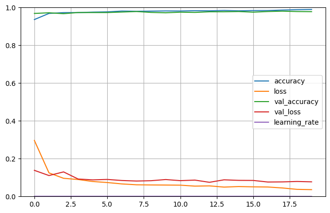

```python
pd.DataFrame(history.history).plot(figsize=(8,5))
plt.grid(True)
plt.gca().set_ylim(0, 1)
plt.show()
```

```python
total_loss, total_accuracy = WaD_model.evaluate(
    X_test_prepared,
    y_test
)

print(f"Total Loss: {total_loss}")
print(f"Total Accuracy: {total_accuracy}")
```

[output not shown]

## **Enhancing Model Performance: Batch Normalization and Regularization**

To improve our model's stability and generalization, let's incorporate **Batch Normalization** and apply **$\ell_1$ and $\ell_2$ Regularization**. These techniques will help to prevent overfitting and ensure better convergence during training.

### Batch Normalization (BN)

- Normalizes the inputs to each hidden layer by zero-centering and scaling them. It then uses two learnable parameters per layer to scale and shift the results, allowing the model to learn the optimal input mean and variance.
- During testing, Keras uses a moving average of the input means and standard deviations, calculated during training, to normalize inputs when making predictions.

### $\ell_1$ Regularization (Lasso)

- Adds the absolute value of weights to the loss function.
- Encourages sparsity, forcing many weights to zero, making it useful for feature selection.

### $\ell_2$ Regularization (Ridge)

- Adds the squared value of weights to the loss function.
- Penalizes large weights, encouraging more even weight distribution without forcing them to zero.

Now we also need to include a @property call. This is for an issue we would have faced later when we want to doing a RandomizedSearchCV to fine tune our model. We will be using scikeras `KerasRegressor`, which is a thin wrapper around our Keras model to act like a regular Scikit-Learn regressor which we can fit(), score(), and predict() with.

However, our subclassed ImprovedWideAndDeepModel already has an "output" property, and scikeras expects our model to have an "outputs" attribute. To fix this, we need to make ImprovedWideAndDeepModel behave like a typical Keras model by having an "outputs" attribute, so we override the output property to return a list of outputs (as expected by scikeras).

```python
@keras.utils.register_keras_serializable()
class ImprovedWideAndDeepModel(keras.Model):
    def __init__(self, n_hidden=3, n_neurons=[100, 50, 16], l1_reg=0.001, l2_reg=0.001, **kwargs):
        super().__init__(**kwargs)
        self.n_hidden = n_hidden
        self.n_neurons = n_neurons
        self.l1_reg = l1_reg
        self.l2_reg = l2_reg
        self.regularizer = regularizers.l1_l2(l1=l1_reg, l2=l2_reg)
        self.kernel_initializer = 'he_normal'
        self.input_shape_value = (9,)
        self.activation_function = LeakyReLU(alpha=0.01)

        # Input Layer
        self.input_layer = keras.layers.InputLayer(input_shape=self.input_shape_value)

        # Hidden Layers (Deep Path)
        self.hidden_layers = [
            keras.layers.Dense(n_neurons[i], activation=None,
                               kernel_regularizer=self.regularizer, # L1/L2 Regularizer
                               kernel_initializer=self.kernel_initializer)
            for i in range(n_hidden)
        ]

        #Batch Normalization
        self.batch_norm_layers = [BatchNormalization() for _ in range(n_hidden+1)]


        #Batch Normalization
        self.batch_norm_final = [BatchNormalization() for _ in range(n_hidden+1)]

        # Concatenate Layer (Wide Path)
        self.concat = keras.layers.Concatenate()

        # Final Hidden Layer
        self.hidden_final = keras.layers.Dense(32, activation=self.activation_function,
                                               kernel_initializer=self.kernel_initializer)

        # Output Layer
        self.target_type_output = keras.layers.Dense(6, activation="softmax", name="target_type_output",
                                                     kernel_initializer=self.kernel_initializer)

    def call(self, inputs):
        x = inputs
        for layer, batch_norm in zip(self.hidden_layers, self.batch_norm_layers):
            x = layer(x)
            x = batch_norm(x)
            x = self.activation_function(x)
        inputs_norm = self.batch_norm_final[0](inputs)
        concat = self.concat([inputs_norm, x])
        hidden_final = self.hidden_final(concat)
        output = self.target_type_output(hidden_final)

        return output

    def get_config(self):
        config = super().get_config()
        config.update({
            "n_hidden": self.n_hidden,
            "n_neurons": self.n_neurons,
            "l1_reg": self.l1_reg,
            "l2_reg": self.l2_reg
        })
        return config

    @property
    def outputs(self):
        return [self.target_type_output]
```

```python
WaD_model_improved = ImprovedWideAndDeepModel(
    n_hidden=3,
    n_neurons=[100, 50, 16],
    l1_reg=0.001,
    l2_reg=0.001
)
```

```python
WaD_model_improved.compile(
    optimizer=keras.optimizers.Adam(learning_rate=0.001),
    loss="sparse_categorical_crossentropy",
    metrics=["accuracy"]
)
```

```python
WaD_model_improved.save("WaD_model_improved.keras")
```

```python
WaD_model_improved.summary()
```

```
Model: "improved_wide_and_deep_model"
```

```
┏━━━━━━━━━━━━━━━━━━━━━━━━━━━━━━━━━┳━━━━━━━━━━━━━━━━━━━━━━━━┳━━━━━━━━━━━━━━━┓
┃ Layer (type)                    ┃ Output Shape           ┃       Param # ┃
┡━━━━━━━━━━━━━━━━━━━━━━━━━━━━━━━━━╇━━━━━━━━━━━━━━━━━━━━━━━━╇━━━━━━━━━━━━━━━┩
│ leaky_re_lu_2 (LeakyReLU)       │ ?                      │             0 │
├─────────────────────────────────┼────────────────────────┼───────────────┤
│ input_layer_2 (InputLayer)      │ (None, 9)              │             0 │
├─────────────────────────────────┼────────────────────────┼───────────────┤
│ dense_8 (Dense)                 │ ?                      │   0 (unbuilt) │
├─────────────────────────────────┼────────────────────────┼───────────────┤
│ dense_9 (Dense)                 │ ?                      │   0 (unbuilt) │
├─────────────────────────────────┼────────────────────────┼───────────────┤
│ dense_10 (Dense)                │ ?                      │   0 (unbuilt) │
├─────────────────────────────────┼────────────────────────┼───────────────┤
│ batch_normalization             │ ?                      │   0 (unbuilt) │
│ (BatchNormalization)            │                        │               │
├─────────────────────────────────┼────────────────────────┼───────────────┤
│ batch_normalization_1           │ ?                      │   0 (unbuilt) │
│ (BatchNormalization)            │                        │               │
├─────────────────────────────────┼────────────────────────┼───────────────┤
│ batch_normalization_2           │ ?                      │   0 (unbuilt) │
│ (BatchNormalization)            │                        │               │
├─────────────────────────────────┼────────────────────────┼───────────────┤
│ batch_normalization_3           │ ?                      │   0 (unbuilt) │
│ (BatchNormalization)            │                        │               │
├─────────────────────────────────┼────────────────────────┼───────────────┤
│ batch_normalization_4           │ ?                      │   0 (unbuilt) │
│ (BatchNormalization)            │                        │               │
├─────────────────────────────────┼────────────────────────┼───────────────┤
│ batch_normalization_5           │ ?                      │   0 (unbuilt) │
│ (BatchNormalization)            │                        │               │
├─────────────────────────────────┼────────────────────────┼───────────────┤
│ batch_normalization_6           │ ?                      │   0 (unbuilt) │
│ (BatchNormalization)            │                        │               │
├─────────────────────────────────┼────────────────────────┼───────────────┤
│ batch_normalization_7           │ ?                      │   0 (unbuilt) │
│ (BatchNormalization)            │                        │               │
├─────────────────────────────────┼────────────────────────┼───────────────┤
│ concatenate_2 (Concatenate)     │ ?                      │   0 (unbuilt) │
├─────────────────────────────────┼────────────────────────┼───────────────┤
│ dense_11 (Dense)                │ ?                      │   0 (unbuilt) │
├─────────────────────────────────┼────────────────────────┼───────────────┤
│ target_type_output (Dense)      │ ?                      │   0 (unbuilt) │
└─────────────────────────────────┴────────────────────────┴───────────────┘
```

```
 Total params: 0 (0.00 B)
```

```
 Trainable params: 0 (0.00 B)
```

```
 Non-trainable params: 0 (0.00 B)
```

```python
WaD_model_improved.layers
```

```
[<LeakyReLU name=leaky_re_lu_2, built=True>,
 <InputLayer name=input_layer_2, built=True>,
 <Dense name=dense_8, built=False>,
 <Dense name=dense_9, built=False>,
 <Dense name=dense_10, built=False>,
 <BatchNormalization name=batch_normalization, built=False>,
 <BatchNormalization name=batch_normalization_1, built=False>,
 <BatchNormalization name=batch_normalization_2, built=False>,
 <BatchNormalization name=batch_normalization_3, built=False>,
 <BatchNormalization name=batch_normalization_4, built=False>,
 <BatchNormalization name=batch_normalization_5, built=False>,
 <BatchNormalization name=batch_normalization_6, built=False>,
 <BatchNormalization name=batch_normalization_7, built=False>,
 <Concatenate name=concatenate_2, built=False>,
 <Dense name=dense_11, built=False>,
 <Dense name=target_type_output, built=False>]
```

```python
root_logdir = os.path.join(os.curdir, "Logs", "Wide And Deep Improved Model")

def get_run_logdir():
    run_id = time.strftime("run_%Y_%m_%d-%H_%M_%S")

    return os.path.join(root_logdir, run_id)

run_logdir = get_run_logdir()

os.makedirs(run_logdir, exist_ok=True)
```

```python
checkpoint_cb = keras.callbacks.ModelCheckpoint("WaD_model_improved.keras", save_best_only=True)
early_stopping_cb = keras.callbacks.EarlyStopping(monitor='val_loss', patience=7, restore_best_weights=True)
tensorboard_cb = keras.callbacks.TensorBoard(run_logdir)
reduce_lr = ReduceLROnPlateau(monitor="val_loss", factor=0.5, patience=5, min_lr=1e-5)


history = WaD_model_improved.fit(
    X_train_prepared,
    y_train,
    epochs=200,
    validation_data=(
        X_valid_prepared,
        y_valid
    ),
    callbacks=[checkpoint_cb, early_stopping_cb, tensorboard_cb, reduce_lr]
)
```

```
219/219 ━━━━━━━━━━━━━━━━━━━━ 1s 2ms/step - accuracy: 0.9402 - loss: 1.5967 - val_accuracy: 0.9680 - val_loss: 1.0318 - learning_rate: 0.0010
219/219 ━━━━━━━━━━━━━━━━━━━━ 0s 892us/step - accuracy: 0.9679 - loss: 0.9568 - val_accuracy: 0.9694 - val_loss: 0.7465 - learning_rate: 0.0010
219/219 ━━━━━━━━━━━━━━━━━━━━ 0s 859us/step - accuracy: 0.9725 - loss: 0.6839 - val_accuracy: 0.9694 - val_loss: 0.5643 - learning_rate: 0.0010
219/219 ━━━━━━━━━━━━━━━━━━━━ 0s 845us/step - accuracy: 0.9695 - loss: 0.5225 - val_accuracy: 0.9707 - val_loss: 0.4350 - learning_rate: 0.0010
219/219 ━━━━━━━━━━━━━━━━━━━━ 0s 851us/step - accuracy: 0.9711 - loss: 0.4074 - val_accuracy: 0.9714 - val_loss: 0.3491 - learning_rate: 0.0010
219/219 ━━━━━━━━━━━━━━━━━━━━ 0s 880us/step - accuracy: 0.9739 - loss: 0.3260 - val_accuracy: 0.9687 - val_loss: 0.2902 - learning_rate: 0.0010
219/219 ━━━━━━━━━━━━━━━━━━━━ 0s 845us/step - accuracy: 0.9738 - loss: 0.2719 - val_accuracy: 0.9694 - val_loss: 0.2435 - learning_rate: 0.0010
219/219 ━━━━━━━━━━━━━━━━━━━━ 0s 838us/step - accuracy: 0.9747 - loss: 0.2282 - val_accuracy: 0.9694 - val_loss: 0.2156 - learning_rate: 0.0010
219/219 ━━━━━━━━━━━━━━━━━━━━ 0s 841us/step - accuracy: 0.9761 - loss: 0.1878 - val_accuracy: 0.9707 - val_loss: 0.1879 - learning_rate: 0.0010
219/219 ━━━━━━━━━━━━━━━━━━━━ 0s 835us/step - accuracy: 0.9740 - loss: 0.1731 - val_accuracy: 0.9707 - val_loss: 0.1729 - learning_rate: 0.0010
219/219 ━━━━━━━━━━━━━━━━━━━━ 0s 835us/step - accuracy: 0.9717 - loss: 0.1646 - val_accuracy: 0.9714 - val_loss: 0.1541 - learning_rate: 0.0010
219/219 ━━━━━━━━━━━━━━━━━━━━ 0s 835us/step - accuracy: 0.9764 - loss: 0.1361 - val_accuracy: 0.9694 - val_loss: 0.1523 - learning_rate: 0.0010
219/219 ━━━━━━━━━━━━━━━━━━━━ 0s 823us/step - accuracy: 0.9758 - loss: 0.1305 - val_accuracy: 0.9714 - val_loss: 0.1354 - learning_rate: 0.0010
219/219 ━━━━━━━━━━━━━━━━━━━━ 0s 834us/step - accuracy: 0.9726 - loss: 0.1439 - val_accuracy: 0.9714 - val_loss: 0.1354 - learning_rate: 0.0010
219/219 ━━━━━━━━━━━━━━━━━━━━ 0s 843us/step - accuracy: 0.9793 - loss: 0.1143 - val_accuracy: 0.9747 - val_loss: 0.1245 - learning_rate: 0.0010
219/219 ━━━━━━━━━━━━━━━━━━━━ 0s 832us/step - accuracy: 0.9732 - loss: 0.1133 - val_accuracy: 0.9747 - val_loss: 0.1176 - learning_rate: 0.0010
219/219 ━━━━━━━━━━━━━━━━━━━━ 0s 833us/step - accuracy: 0.9789 - loss: 0.0982 - val_accuracy: 0.9787 - val_loss: 0.1155 - learning_rate: 0.0010
219/219 ━━━━━━━━━━━━━━━━━━━━ 0s 834us/step - accuracy: 0.9792 - loss: 0.0981 - val_accuracy: 0.9714 - val_loss: 0.1140 - learning_rate: 0.0010
219/219 ━━━━━━━━━━━━━━━━━━━━ 0s 748us/step - accuracy: 0.9798 - loss: 0.0960 - val_accuracy: 0.9740 - val_loss: 0.1160 - learning_rate: 0.0010
219/219 ━━━━━━━━━━━━━━━━━━━━ 0s 819us/step - accuracy: 0.9777 - loss: 0.0965 - val_accuracy: 0.9753 - val_loss: 0.1065 - learning_rate: 0.0010
219/219 ━━━━━━━━━━━━━━━━━━━━ 0s 747us/step - accuracy: 0.9781 - loss: 0.1006 - val_accuracy: 0.9767 - val_loss: 0.1070 - learning_rate: 0.0010
219/219 ━━━━━━━━━━━━━━━━━━━━ 0s 747us/step - accuracy: 0.9791 - loss: 0.0909 - val_accuracy: 0.9734 - val_loss: 0.1083 - learning_rate: 0.0010
219/219 ━━━━━━━━━━━━━━━━━━━━ 0s 832us/step - accuracy: 0.9757 - loss: 0.0904 - val_accuracy: 0.9760 - val_loss: 0.1011 - learning_rate: 0.0010
219/219 ━━━━━━━━━━━━━━━━━━━━ 0s 750us/step - accuracy: 0.9790 - loss: 0.0810 - val_accuracy: 0.9793 - val_loss: 0.1015 - learning_rate: 0.0010
219/219 ━━━━━━━━━━━━━━━━━━━━ 0s 826us/step - accuracy: 0.9815 - loss: 0.0782 - val_accuracy: 0.9753 - val_loss: 0.0976 - learning_rate: 0.0010
219/219 ━━━━━━━━━━━━━━━━━━━━ 0s 750us/step - accuracy: 0.9825 - loss: 0.0757 - val_accuracy: 0.9760 - val_loss: 0.0976 - learning_rate: 0.0010
219/219 ━━━━━━━━━━━━━━━━━━━━ 0s 830us/step - accuracy: 0.9808 - loss: 0.0756 - val_accuracy: 0.9787 - val_loss: 0.0963 - learning_rate: 0.0010
219/219 ━━━━━━━━━━━━━━━━━━━━ 0s 780us/step - accuracy: 0.9795 - loss: 0.0752 - val_accuracy: 0.9780 - val_loss: 0.0992 - learning_rate: 0.0010
219/219 ━━━━━━━━━━━━━━━━━━━━ 0s 837us/step - accuracy: 0.9813 - loss: 0.0717 - val_accuracy: 0.9780 - val_loss: 0.0933 - learning_rate: 0.0010
219/219 ━━━━━━━━━━━━━━━━━━━━ 0s 838us/step - accuracy: 0.9789 - loss: 0.0809 - val_accuracy: 0.9780 - val_loss: 0.0917 - learning_rate: 0.0010
219/219 ━━━━━━━━━━━━━━━━━━━━ 0s 750us/step - accuracy: 0.9786 - loss: 0.0761 - val_accuracy: 0.9734 - val_loss: 0.0974 - learning_rate: 0.0010
219/219 ━━━━━━━━━━━━━━━━━━━━ 0s 832us/step - accuracy: 0.9815 - loss: 0.0723 - val_accuracy: 0.9787 - val_loss: 0.0894 - learning_rate: 0.0010
219/219 ━━━━━━━━━━━━━━━━━━━━ 0s 755us/step - accuracy: 0.9855 - loss: 0.0654 - val_accuracy: 0.9793 - val_loss: 0.0906 - learning_rate: 0.0010
219/219 ━━━━━━━━━━━━━━━━━━━━ 0s 748us/step - accuracy: 0.9832 - loss: 0.0697 - val_accuracy: 0.9773 - val_loss: 0.0916 - learning_rate: 0.0010
```

[output cut: 18 more lines]

```python
WaD_model_improved = keras.models.load_model("WaD_model_improved.keras", custom_objects={"ImprovedWideAndDeepModel": ImprovedWideAndDeepModel, "LeakyReLU": LeakyReLU})
```

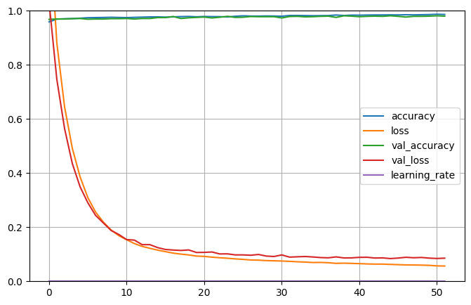

```python
pd.DataFrame(history.history).plot(figsize=(8,5))
plt.grid(True)
plt.gca().set_ylim(0, 1)
plt.show()
```

```python
total_loss, total_accuracy = WaD_model_improved.evaluate(
    X_test_prepared,
    y_test
)

print(f"Total Loss: {total_loss}")
print(f"Total Accuracy: {total_accuracy}")
```

```
47/47 ━━━━━━━━━━━━━━━━━━━━ 0s 492us/step - accuracy: 0.9889 - loss: 0.0458
Total Loss: 0.056278057396411896
Total Accuracy: 0.9853430986404419
```

## **Fine-Tuning Our Model: Hyperparameter Optimization**

To fine-tune our model, we'll use SciKeras' `KerasRegressor` to wrap our model, enabling us to use it as an estimator for hyperparameter optimization with `RandomizedSearchCV`.

We'll perform a randomized search to identify the optimal values for key hyperparameters, including the number of hidden layers, the number of neurons per layer, the $\ell_1$ and $\ell_2$ regularization strengths, and the learning rate.

When using SciKeras, it's important to prefix model parameters with `model__` in the `param_distribs` dictionary. This ensures that `RandomizedSearchCV` correctly identifies them as arguments for the `build_WaD_model()` function.

```python
def build_WaD_model(n_hidden=3, n_neurons=[100, 50, 16], l1_reg=0.001, l2_reg=0.001, learning_rate=0.001):
    model = ImprovedWideAndDeepModel(n_hidden=n_hidden,
                             n_neurons=n_neurons,
                             l1_reg=l1_reg,
                             l2_reg=l2_reg)

    model.compile(optimizer=keras.optimizers.Adam(learning_rate=learning_rate),
                  loss="sparse_categorical_crossentropy",
                  metrics=["accuracy"])

    return model
```

```python
keras_reg = KerasRegressor(model=build_WaD_model, epochs=200, batch_size=32, verbose=1)
```

```python
param_distribs = {
    "model__n_hidden": [3],
    "model__n_neurons": [
        [50, 32, 16],
        [100, 50, 16],
        [150, 75, 25],
        [200, 100, 32],
    ],
    "model__l1_reg": [0.01, 0.005, 0.001],
    "model__l2_reg": [0.01, 0.005, 0.001],
    "model__learning_rate": [0.01, 0.005, 0.001]
}

rnd_search_cv = RandomizedSearchCV(
    estimator=keras_reg,
    param_distributions=param_distribs,
    n_iter=20,
    cv=3,
    verbose=1,
    refit=False
)
```

```python
early_stopping_cb = keras.callbacks.EarlyStopping(monitor='val_loss', patience=7, restore_best_weights=True)
reduce_lr = ReduceLROnPlateau(monitor="val_loss", factor=0.5, patience=5, min_lr=1e-5)

rnd_search_cv.fit(
    X_train_prepared,
    y_train,
    validation_data=(
        X_valid_prepared,
        y_valid
    ),
    callbacks=[early_stopping_cb, reduce_lr]
)
```

```
Fitting 3 folds for each of 20 candidates, totalling 60 fits
146/146 ━━━━━━━━━━━━━━━━━━━━ 1s 2ms/step - accuracy: 0.9310 - loss: 3.3684 - val_accuracy: 0.9587 - val_loss: 0.2029
146/146 ━━━━━━━━━━━━━━━━━━━━ 0s 777us/step - accuracy: 0.9657 - loss: 0.1667 - val_accuracy: 0.9667 - val_loss: 0.1905
146/146 ━━━━━━━━━━━━━━━━━━━━ 0s 744us/step - accuracy: 0.9630 - loss: 0.1560 - val_accuracy: 0.9714 - val_loss: 0.1393
146/146 ━━━━━━━━━━━━━━━━━━━━ 0s 817us/step - accuracy: 0.9686 - loss: 0.1279 - val_accuracy: 0.9667 - val_loss: 0.1530
146/146 ━━━━━━━━━━━━━━━━━━━━ 0s 755us/step - accuracy: 0.9706 - loss: 0.1263 - val_accuracy: 0.9654 - val_loss: 0.1565
146/146 ━━━━━━━━━━━━━━━━━━━━ 0s 726us/step - accuracy: 0.9713 - loss: 0.1287 - val_accuracy: 0.9720 - val_loss: 0.1478
146/146 ━━━━━━━━━━━━━━━━━━━━ 0s 729us/step - accuracy: 0.9733 - loss: 0.1133 - val_accuracy: 0.9720 - val_loss: 0.1458
146/146 ━━━━━━━━━━━━━━━━━━━━ 0s 720us/step - accuracy: 0.9717 - loss: 0.1248 - val_accuracy: 0.9740 - val_loss: 0.1304
146/146 ━━━━━━━━━━━━━━━━━━━━ 0s 710us/step - accuracy: 0.9776 - loss: 0.1111 - val_accuracy: 0.9773 - val_loss: 0.1258
146/146 ━━━━━━━━━━━━━━━━━━━━ 0s 798us/step - accuracy: 0.9767 - loss: 0.1237 - val_accuracy: 0.9753 - val_loss: 0.1386
146/146 ━━━━━━━━━━━━━━━━━━━━ 0s 821us/step - accuracy: 0.9769 - loss: 0.1123 - val_accuracy: 0.9700 - val_loss: 0.1381
146/146 ━━━━━━━━━━━━━━━━━━━━ 0s 752us/step - accuracy: 0.9734 - loss: 0.1077 - val_accuracy: 0.9714 - val_loss: 0.1386
146/146 ━━━━━━━━━━━━━━━━━━━━ 0s 774us/step - accuracy: 0.9709 - loss: 0.1224 - val_accuracy: 0.9773 - val_loss: 0.1363
146/146 ━━━━━━━━━━━━━━━━━━━━ 0s 730us/step - accuracy: 0.9803 - loss: 0.1037 - val_accuracy: 0.9740 - val_loss: 0.1574
146/146 ━━━━━━━━━━━━━━━━━━━━ 0s 735us/step - accuracy: 0.9795 - loss: 0.1078 - val_accuracy: 0.9740 - val_loss: 0.1468
146/146 ━━━━━━━━━━━━━━━━━━━━ 0s 724us/step - accuracy: 0.9768 - loss: 0.1181 - val_accuracy: 0.9747 - val_loss: 0.1533
146/146 ━━━━━━━━━━━━━━━━━━━━ 0s 990us/step - accuracy: 0.9823 - loss: 0.1000 - val_accuracy: 0.9747 - val_loss: 0.1376
146/146 ━━━━━━━━━━━━━━━━━━━━ 0s 815us/step - accuracy: 0.9793 - loss: 0.1021 - val_accuracy: 0.9753 - val_loss: 0.1305
146/146 ━━━━━━━━━━━━━━━━━━━━ 0s 808us/step - accuracy: 0.9812 - loss: 0.0983 - val_accuracy: 0.9727 - val_loss: 0.1797
146/146 ━━━━━━━━━━━━━━━━━━━━ 0s 737us/step - accuracy: 0.9792 - loss: 0.1146 - val_accuracy: 0.9780 - val_loss: 0.1329
146/146 ━━━━━━━━━━━━━━━━━━━━ 0s 715us/step - accuracy: 0.9864 - loss: 0.0860 - val_accuracy: 0.9707 - val_loss: 0.1458
146/146 ━━━━━━━━━━━━━━━━━━━━ 0s 715us/step - accuracy: 0.9798 - loss: 0.0963 - val_accuracy: 0.9773 - val_loss: 0.1498
146/146 ━━━━━━━━━━━━━━━━━━━━ 0s 726us/step - accuracy: 0.9827 - loss: 0.0970 - val_accuracy: 0.9813 - val_loss: 0.1303
146/146 ━━━━━━━━━━━━━━━━━━━━ 0s 722us/step - accuracy: 0.9804 - loss: 0.1043 - val_accuracy: 0.9740 - val_loss: 0.1397
146/146 ━━━━━━━━━━━━━━━━━━━━ 0s 717us/step - accuracy: 0.9841 - loss: 0.0963 - val_accuracy: 0.9773 - val_loss: 0.1332
146/146 ━━━━━━━━━━━━━━━━━━━━ 0s 723us/step - accuracy: 0.9848 - loss: 0.0899 - val_accuracy: 0.9780 - val_loss: 0.1377
146/146 ━━━━━━━━━━━━━━━━━━━━ 0s 713us/step - accuracy: 0.9812 - loss: 0.0939 - val_accuracy: 0.9694 - val_loss: 0.1457
146/146 ━━━━━━━━━━━━━━━━━━━━ 0s 759us/step - accuracy: 0.9808 - loss: 0.1015 - val_accuracy: 0.9700 - val_loss: 0.1513
146/146 ━━━━━━━━━━━━━━━━━━━━ 0s 763us/step - accuracy: 0.9832 - loss: 0.0909 - val_accuracy: 0.9640 - val_loss: 0.1854
146/146 ━━━━━━━━━━━━━━━━━━━━ 0s 731us/step - accuracy: 0.9791 - loss: 0.1032 - val_accuracy: 0.9720 - val_loss: 0.1444
146/146 ━━━━━━━━━━━━━━━━━━━━ 0s 723us/step - accuracy: 0.9890 - loss: 0.0804 - val_accuracy: 0.9694 - val_loss: 0.1597
146/146 ━━━━━━━━━━━━━━━━━━━━ 0s 728us/step - accuracy: 0.9800 - loss: 0.0968 - val_accuracy: 0.9734 - val_loss: 0.1652
146/146 ━━━━━━━━━━━━━━━━━━━━ 0s 728us/step - accuracy: 0.9822 - loss: 0.0974 - val_accuracy: 0.9793 - val_loss: 0.1328
146/146 ━━━━━━━━━━━━━━━━━━━━ 0s 727us/step - accuracy: 0.9839 - loss: 0.0973 - val_accuracy: 0.9800 - val_loss: 0.1306
146/146 ━━━━━━━━━━━━━━━━━━━━ 0s 718us/step - accuracy: 0.9848 - loss: 0.0897 - val_accuracy: 0.9727 - val_loss: 0.1577
146/146 ━━━━━━━━━━━━━━━━━━━━ 0s 720us/step - accuracy: 0.9855 - loss: 0.0849 - val_accuracy: 0.9767 - val_loss: 0.1472
146/146 ━━━━━━━━━━━━━━━━━━━━ 0s 752us/step - accuracy: 0.9801 - loss: 0.1035 - val_accuracy: 0.9760 - val_loss: 0.1469
146/146 ━━━━━━━━━━━━━━━━━━━━ 0s 766us/step - accuracy: 0.9850 - loss: 0.0921 - val_accuracy: 0.9727 - val_loss: 0.1542
146/146 ━━━━━━━━━━━━━━━━━━━━ 0s 947us/step - accuracy: 0.9806 - loss: 0.0938 - val_accuracy: 0.9747 - val_loss: 0.1706
```

[output cut: 580 more lines]

```
146/146 ━━━━━━━━━━━━━━━━━━━━ 0s 1ms/step - accuracy: 0.9738 - loss: 0.0940 - val_accuracy: 0.9734 - val_loss: 0.1073
146/146 ━━━━━━━━━━━━━━━━━━━━ 0s 2ms/step - accuracy: 0.9746 - loss: 0.0904 - val_accuracy: 0.9734 - val_loss: 0.1072
146/146 ━━━━━━━━━━━━━━━━━━━━ 0s 2ms/step - accuracy: 0.9706 - loss: 0.1003 - val_accuracy: 0.9734 - val_loss: 0.1074
146/146 ━━━━━━━━━━━━━━━━━━━━ 0s 1ms/step - accuracy: 0.9731 - loss: 0.0860 - val_accuracy: 0.9734 - val_loss: 0.1061
146/146 ━━━━━━━━━━━━━━━━━━━━ 0s 2ms/step - accuracy: 0.9754 - loss: 0.0963 - val_accuracy: 0.9720 - val_loss: 0.1068
146/146 ━━━━━━━━━━━━━━━━━━━━ 0s 2ms/step - accuracy: 0.9743 - loss: 0.0861 - val_accuracy: 0.9747 - val_loss: 0.1044
146/146 ━━━━━━━━━━━━━━━━━━━━ 0s 1ms/step - accuracy: 0.9731 - loss: 0.0975 - val_accuracy: 0.9740 - val_loss: 0.1050
146/146 ━━━━━━━━━━━━━━━━━━━━ 0s 1ms/step - accuracy: 0.9759 - loss: 0.0903 - val_accuracy: 0.9734 - val_loss: 0.1069
146/146 ━━━━━━━━━━━━━━━━━━━━ 0s 2ms/step - accuracy: 0.9804 - loss: 0.0782 - val_accuracy: 0.9740 - val_loss: 0.1032
146/146 ━━━━━━━━━━━━━━━━━━━━ 0s 1ms/step - accuracy: 0.9759 - loss: 0.0880 - val_accuracy: 0.9734 - val_loss: 0.1046
146/146 ━━━━━━━━━━━━━━━━━━━━ 0s 2ms/step - accuracy: 0.9804 - loss: 0.0777 - val_accuracy: 0.9727 - val_loss: 0.1049
146/146 ━━━━━━━━━━━━━━━━━━━━ 0s 1ms/step - accuracy: 0.9742 - loss: 0.0862 - val_accuracy: 0.9740 - val_loss: 0.1054
146/146 ━━━━━━━━━━━━━━━━━━━━ 0s 2ms/step - accuracy: 0.9797 - loss: 0.0871 - val_accuracy: 0.9747 - val_loss: 0.1018
146/146 ━━━━━━━━━━━━━━━━━━━━ 0s 1ms/step - accuracy: 0.9759 - loss: 0.0877 - val_accuracy: 0.9753 - val_loss: 0.1016
  1/146 ━━━━━━━━━━━━━━━━━━━━ 2s 16ms/step - accuracy: 0.9688 - loss: 0.0883
```

```python
rnd_search_cv.best_params_
```

```
{'model__n_neurons': [100, 50, 16],
 'model__n_hidden': 3,
 'model__learning_rate': 0.01,
 'model__l2_reg': 0.005,
 'model__l1_reg': 0.005}
```

Using RandomizedSearchCV, we found that our best hyperparameters. We can rebuild our ImprovedWideAndDeepModel using these hyperparameters to create our final model.

## **Final Model: Training and Saving the Optimized Model**

After performing hyperparameter tuning, we’ve identified the best parameters for our model. Let's now create the final version of our **Improved Wide and Deep Model** using the optimal values for the number of hidden layers, neurons, regularization strengths, and learning rate.

```python
best_params = rnd_search_cv.best_params_

final_model = ImprovedWideAndDeepModel(
    n_hidden=best_params['model__n_hidden'],
    n_neurons=best_params['model__n_neurons'],
    l1_reg=best_params['model__l1_reg'],
    l2_reg=best_params['model__l2_reg']
)

final_model.compile(
    optimizer=keras.optimizers.Adam(learning_rate=best_params['model__learning_rate']),
    loss='sparse_categorical_crossentropy',
    metrics=['accuracy']
)

final_model.save("WaD_model_final.keras")
```

```python
root_logdir = os.path.join(os.curdir, "Logs", "Wide And Deep Final Model")

def get_run_logdir():
    run_id = time.strftime("run_%Y_%m_%d-%H_%M_%S")

    return os.path.join(root_logdir, run_id)

run_logdir = get_run_logdir()

os.makedirs(run_logdir, exist_ok=True)
```

```python
checkpoint_cb = keras.callbacks.ModelCheckpoint("WaD_model_final.keras", save_best_only=True)
early_stopping_cb = keras.callbacks.EarlyStopping(monitor='val_loss', patience=7, restore_best_weights=True)
tensorboard_cb = keras.callbacks.TensorBoard(run_logdir)
reduce_lr = ReduceLROnPlateau(monitor="val_loss", factor=0.5, patience=5, min_lr=1e-5)

history = final_model.fit(
    X_train_prepared,
    y_train,
    epochs=200,
    validation_data=(X_valid_prepared, y_valid),
    callbacks=[checkpoint_cb, tensorboard_cb, early_stopping_cb, reduce_lr]
)
```

```
219/219 ━━━━━━━━━━━━━━━━━━━━ 3s 3ms/step - accuracy: 0.9409 - loss: 2.6629 - val_accuracy: 0.9687 - val_loss: 0.1511 - learning_rate: 0.0100
219/219 ━━━━━━━━━━━━━━━━━━━━ 0s 2ms/step - accuracy: 0.9717 - loss: 0.1329 - val_accuracy: 0.9694 - val_loss: 0.1436 - learning_rate: 0.0100
219/219 ━━━━━━━━━━━━━━━━━━━━ 0s 2ms/step - accuracy: 0.9735 - loss: 0.1296 - val_accuracy: 0.9667 - val_loss: 0.1572 - learning_rate: 0.0100
219/219 ━━━━━━━━━━━━━━━━━━━━ 0s 2ms/step - accuracy: 0.9720 - loss: 0.1295 - val_accuracy: 0.9707 - val_loss: 0.1394 - learning_rate: 0.0100
219/219 ━━━━━━━━━━━━━━━━━━━━ 0s 2ms/step - accuracy: 0.9768 - loss: 0.1139 - val_accuracy: 0.9707 - val_loss: 0.1451 - learning_rate: 0.0100
219/219 ━━━━━━━━━━━━━━━━━━━━ 0s 2ms/step - accuracy: 0.9763 - loss: 0.1206 - val_accuracy: 0.9687 - val_loss: 0.1468 - learning_rate: 0.0100
219/219 ━━━━━━━━━━━━━━━━━━━━ 0s 2ms/step - accuracy: 0.9771 - loss: 0.1112 - val_accuracy: 0.9787 - val_loss: 0.1362 - learning_rate: 0.0100
219/219 ━━━━━━━━━━━━━━━━━━━━ 0s 2ms/step - accuracy: 0.9799 - loss: 0.1145 - val_accuracy: 0.9800 - val_loss: 0.1256 - learning_rate: 0.0100
219/219 ━━━━━━━━━━━━━━━━━━━━ 0s 2ms/step - accuracy: 0.9815 - loss: 0.0993 - val_accuracy: 0.9734 - val_loss: 0.1379 - learning_rate: 0.0100
219/219 ━━━━━━━━━━━━━━━━━━━━ 1s 2ms/step - accuracy: 0.9770 - loss: 0.1147 - val_accuracy: 0.9747 - val_loss: 0.1352 - learning_rate: 0.0100
219/219 ━━━━━━━━━━━━━━━━━━━━ 0s 2ms/step - accuracy: 0.9793 - loss: 0.1059 - val_accuracy: 0.9807 - val_loss: 0.1196 - learning_rate: 0.0100
219/219 ━━━━━━━━━━━━━━━━━━━━ 0s 2ms/step - accuracy: 0.9812 - loss: 0.1023 - val_accuracy: 0.9793 - val_loss: 0.1344 - learning_rate: 0.0100
219/219 ━━━━━━━━━━━━━━━━━━━━ 0s 2ms/step - accuracy: 0.9812 - loss: 0.1106 - val_accuracy: 0.9813 - val_loss: 0.1218 - learning_rate: 0.0100
219/219 ━━━━━━━━━━━━━━━━━━━━ 0s 2ms/step - accuracy: 0.9835 - loss: 0.0958 - val_accuracy: 0.9760 - val_loss: 0.1378 - learning_rate: 0.0100
219/219 ━━━━━━━━━━━━━━━━━━━━ 0s 2ms/step - accuracy: 0.9821 - loss: 0.1014 - val_accuracy: 0.9753 - val_loss: 0.1304 - learning_rate: 0.0100
219/219 ━━━━━━━━━━━━━━━━━━━━ 0s 2ms/step - accuracy: 0.9820 - loss: 0.0987 - val_accuracy: 0.9720 - val_loss: 0.1510 - learning_rate: 0.0100
219/219 ━━━━━━━━━━━━━━━━━━━━ 0s 2ms/step - accuracy: 0.9851 - loss: 0.0795 - val_accuracy: 0.9787 - val_loss: 0.0999 - learning_rate: 0.0050
219/219 ━━━━━━━━━━━━━━━━━━━━ 0s 2ms/step - accuracy: 0.9871 - loss: 0.0650 - val_accuracy: 0.9813 - val_loss: 0.1018 - learning_rate: 0.0050
219/219 ━━━━━━━━━━━━━━━━━━━━ 0s 2ms/step - accuracy: 0.9860 - loss: 0.0735 - val_accuracy: 0.9793 - val_loss: 0.1019 - learning_rate: 0.0050
219/219 ━━━━━━━━━━━━━━━━━━━━ 0s 2ms/step - accuracy: 0.9874 - loss: 0.0658 - val_accuracy: 0.9780 - val_loss: 0.1023 - learning_rate: 0.0050
219/219 ━━━━━━━━━━━━━━━━━━━━ 0s 2ms/step - accuracy: 0.9852 - loss: 0.0615 - val_accuracy: 0.9840 - val_loss: 0.0969 - learning_rate: 0.0050
219/219 ━━━━━━━━━━━━━━━━━━━━ 0s 2ms/step - accuracy: 0.9876 - loss: 0.0659 - val_accuracy: 0.9800 - val_loss: 0.1063 - learning_rate: 0.0050
219/219 ━━━━━━━━━━━━━━━━━━━━ 0s 1ms/step - accuracy: 0.9851 - loss: 0.0644 - val_accuracy: 0.9820 - val_loss: 0.1025 - learning_rate: 0.0050
219/219 ━━━━━━━━━━━━━━━━━━━━ 0s 2ms/step - accuracy: 0.9854 - loss: 0.0640 - val_accuracy: 0.9807 - val_loss: 0.0961 - learning_rate: 0.0050
219/219 ━━━━━━━━━━━━━━━━━━━━ 0s 2ms/step - accuracy: 0.9877 - loss: 0.0609 - val_accuracy: 0.9827 - val_loss: 0.1033 - learning_rate: 0.0050
219/219 ━━━━━━━━━━━━━━━━━━━━ 0s 2ms/step - accuracy: 0.9863 - loss: 0.0625 - val_accuracy: 0.9847 - val_loss: 0.0971 - learning_rate: 0.0050
219/219 ━━━━━━━━━━━━━━━━━━━━ 0s 1ms/step - accuracy: 0.9882 - loss: 0.0613 - val_accuracy: 0.9847 - val_loss: 0.0991 - learning_rate: 0.0050
219/219 ━━━━━━━━━━━━━━━━━━━━ 0s 2ms/step - accuracy: 0.9901 - loss: 0.0556 - val_accuracy: 0.9813 - val_loss: 0.1059 - learning_rate: 0.0050
219/219 ━━━━━━━━━━━━━━━━━━━━ 0s 2ms/step - accuracy: 0.9877 - loss: 0.0648 - val_accuracy: 0.9813 - val_loss: 0.1002 - learning_rate: 0.0050
219/219 ━━━━━━━━━━━━━━━━━━━━ 0s 2ms/step - accuracy: 0.9887 - loss: 0.0531 - val_accuracy: 0.9833 - val_loss: 0.0879 - learning_rate: 0.0025
219/219 ━━━━━━━━━━━━━━━━━━━━ 0s 2ms/step - accuracy: 0.9900 - loss: 0.0456 - val_accuracy: 0.9827 - val_loss: 0.0909 - learning_rate: 0.0025
219/219 ━━━━━━━━━━━━━━━━━━━━ 0s 2ms/step - accuracy: 0.9896 - loss: 0.0444 - val_accuracy: 0.9807 - val_loss: 0.0895 - learning_rate: 0.0025
219/219 ━━━━━━━━━━━━━━━━━━━━ 0s 2ms/step - accuracy: 0.9890 - loss: 0.0481 - val_accuracy: 0.9847 - val_loss: 0.0899 - learning_rate: 0.0025
219/219 ━━━━━━━━━━━━━━━━━━━━ 0s 2ms/step - accuracy: 0.9915 - loss: 0.0452 - val_accuracy: 0.9840 - val_loss: 0.0898 - learning_rate: 0.0025
219/219 ━━━━━━━━━━━━━━━━━━━━ 0s 2ms/step - accuracy: 0.9884 - loss: 0.0500 - val_accuracy: 0.9833 - val_loss: 0.0908 - learning_rate: 0.0025
219/219 ━━━━━━━━━━━━━━━━━━━━ 0s 2ms/step - accuracy: 0.9908 - loss: 0.0378 - val_accuracy: 0.9847 - val_loss: 0.0854 - learning_rate: 0.0012
```

[output cut: 18 more lines]

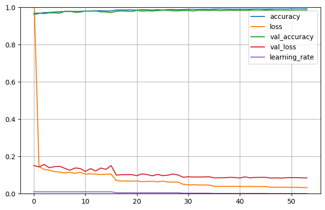

```python
pd.DataFrame(history.history).plot(figsize=(8,5))
plt.grid(True)
plt.gca().set_ylim(0, 1)
plt.show()
```

```python
total_loss, total_accuracy = final_model.evaluate(
    X_test_prepared,
    y_test
)

print(f"Total Loss: {total_loss}")
print(f"Total Accuracy: {total_accuracy}")
```

```
47/47 ━━━━━━━━━━━━━━━━━━━━ 0s 1ms/step - accuracy: 0.9906 - loss: 0.0441
Total Loss: 0.056046806275844574
Total Accuracy: 0.9873417615890503
```

And our results did get slightly better with a higher total accuracy of 98.7% !